# PCFL: Week 14 (and regular season) wrap-up

### Last week’s games

| Away | Away points | Home | Home points |
| --- | --- | --- | --- |
| Athens Team Sasquatch | 120.22 | Georgia Peanuts | 133.72 |
| Middle Earth Hangry Hobbits | 93.86 | Jumpin’ Jaheims | 99.32 |
| The G.O.A.T. | 105.84 | Southern Sharks | 89.24 |
| First Timers The FTs | 79.02 | Captain Clairvoyant | 164.10 |
| KC Gophers | 128.78 | Pigskin on the Gridiron | 92.24 |

This was the last week of the regular season, and the stakes were pretty low. Brian ended up with another very nice week in the win over the First Timers, and all three other playoff teams (Sasquatch, Peanuts, and the GOAT) all topped 100 points, as did Christine (who probably wishes those points came last week).

#### Best performing players

Here’s last week’s **10 best performing players.**

| Player | Points | Team |
| --- | --- | --- |
| Derrick Henry | 35.20 | Captain Clairvoyant |
| Lamar Jackson | 34.92 | Athens Team Sasquatch |
| Aaron Rodgers | 30.90 | Captain Clairvoyant |
| Jonathan Taylor | 29.50 | The G.O.A.T. |
| Miles Sanders | 27.60 | Pigskin on the Gridiron |
| Kareem Hunt | 26.00 | Middle Earth Hangry Hobbits |
| Tyreek Hill | 25.60 | KC Gophers |
| Stefon Diggs | 24.10 | First Timers The FTs |
| Derek Carr | 23.84 | KC Gophers |
| Mike Davis | 23.80 | Athens Team Sasquatch |

Derrick Henry has been an anchor for Captain Clairvoyant, and he had another great week last week. For those of you who missed the end of the Baltimore game, Lamar Jackson had a memorable moment. (You can just Google his name.)

#### Best addition and worst starters

There were 9 players added last week. Which was the **best new addition**?

| Date added | Name | Points | Team |
| --- | --- | --- | --- |
| 2020-12-11 | Mike Davis | 23.80 | Athens Team Sasquatch |
| 2020-12-11 | Washington D/ST | 23.00 | Captain Clairvoyant |
| 2020-12-10 | Cam Akers | 20.40 | Georgia Peanuts |
| 2020-12-10 | Jalen Hurts | 19.28 | Georgia Peanuts |
| 2020-12-13 | Chase Claypool | 3.00 | Jumpin’ Jaheims |
| 2020-12-10 | Corey Davis | 2.90 | Athens Team Sasquatch |
| 2020-12-13 | Cordarrelle Patterson | 2.60 | Athens Team Sasquatch |
| 2020-12-10 | Giovani Bernard | 1.80 | Athens Team Sasquatch |
| 2020-12-10 | Graham Gano | 1.00 | Athens Team Sasquatch |

Mike Davis and Cam Akers both had nice weeks running the ball, and Jalen Hurts cleaned up in his first start. Not a whole lot of pickups this week otherwise.

Who won the **best scoring bench** award last week?

| Team | Points |
| --- | --- |
| KC Gophers | 86.74 |
| Georgia Peanuts | 84.12 |
| Athens Team Sasquatch | 79.66 |
| Captain Clairvoyant | 71.40 |
| The G.O.A.T. | 68.88 |
| Jumpin’ Jaheims | 39.70 |
| Pigskin on the Gridiron | 38.66 |
| Middle Earth Hangry Hobbits | 37.38 |
| Southern Sharks | 30.56 |
| First Timers The FTs | 28.00 |

Gopers made the top of the list this week.

### League standings and season stats

Here’s a look at our *final* regular season standings!

| Team | Division | W | L | Points scored | Points allowed | Points rank | Playoff rank |
| --- | --- | --- | --- | --- | --- | --- | --- |
| Georgia Peanuts | Hot Dish | 11 | 3 | 1873.98 | 1501.66 | 1 | 1 |
| Captain Clairvoyant | Grits | 10 | 4 | 1735.51 | 1539.54 | 2 | 2 |
| Athens Team Sasquatch | Grits | 9 | 5 | 1599.58 | 1532.04 | 3 | 3 |
| The G.O.A.T. | Grits | 9 | 5 | 1533.19 | 1593.94 | 5 | 4 |
| KC Gophers | Hot Dish | 7 | 7 | 1533.72 | 1541.13 | 4 | 5 |
| First Timers The FTs | Hot Dish | 5 | 9 | 1499.24 | 1633.36 | 7 | 6 |
| Pigskin on the Gridiron | Grits | 5 | 9 | 1449.12 | 1606.60 | 8 | 7 |
| Southern Sharks | Hot Dish | 5 | 9 | 1438.22 | 1499.91 | 9 | 8 |
| Jumpin’ Jaheims | Grits | 5 | 9 | 1424.20 | 1558.57 | 10 | 9 |
| Middle Earth Hangry Hobbits | Hot Dish | 4 | 10 | 1506.84 | 1586.85 | 6 | 10 |

Here’s our current awards leaders from these standings:

- Yellow shirt (most points): Georgia Peanuts
- D-FENCE (least points allowed): Southern Sharks *new*
- Tough luck (points rank - playoff rank): Hobbits (6th in points and 10th in the standings)
- Lucky ducks (playoff rank - points rank): A whole bunch of teams ended up here-GOAT, First Timers, Pigskin, Sharks, and Jaheims–all one spot higher in the playoffs than their points would suggest.

I’ll also note the parity here–four teams ended up 5-9 and the Hobbits were 4-10.

Here’s a list of the **top five scoring performances** so far this season.

| Team | Week | Points scored | Result |
| --- | --- | --- | --- |
| Georgia Peanuts | 8 | 183.82 | W |
| Captain Clairvoyant | 12 | 175.34 | W |
| First Timers The FTs | 2 | 171.28 | W |
| Georgia Peanuts | 13 | 170.96 | W |
| Captain Clairvoyant | 14 | 164.10 | W |

The Peanuts held onto the top spot here, but Brian’s Captain Clairvoyant also had a strong run at the end. The First Timers’ week 2 performance rounds out our top 5.

Lastly, here’s a look at the **points trendline** for each team.

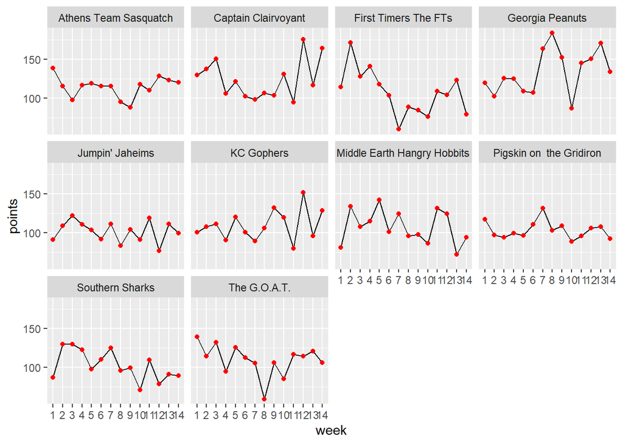

### Playoffs–week 1

Here’s where things get interesting. The playoffs start this week. In some ESPN leagues, each matchup is two weeks long, but that gets to be pretty stretched out. So our league is a one and done over two weeks.

In the championship bracket, this week’s matchups are:

- #1 Peanuts vs. #4 GOAT
- #2 Clairvoyant vs. #3 Sasquatch

The winners advance to the championship matchup.

In the consolation rounds, the matchups are as follows:

- #5 Gophers vs. #6 First Timers
- #7 Pigskin vs. #8 Sharks
- #9 Jaheims vs. #10 Hobbits

Next week’s matchups are more complicated here, but winning is better.

We’re nearing the end, y’all. Good luck to everyone!